# Data Visualization with R

MSDA - Summer Bootcamp 2026

KT Wong

kwanto@hku.hk

Faculty of Social Sciences, HKU

2026-08-27

The materials in this topic are drawn from Imai and Williams (2022), Wickham and Grolemund (2023), Wickham (2019) and Wickham (2016) as well as other sources, including Princeton Sociology Methods Camp 2023. The materials are for educational purposes only.

## ggplot2

it starts from the grammar of graphics Wickham (2016)

- data
- aesthetics
- geoms
- facets
- stats
- scales
- coordinates
- themes

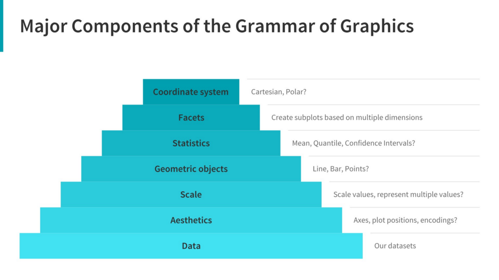

Source: [The Grammar of Graphics](https://link.springer.com/book/10.1007/0-387-28695-0)

## ggplot2

- Every ggplot2 plot has three key components:
  - data
  - A set of **aesthetic mappings** between variables in the data and visual properties
  - At least one layer which describes how to render each observation
    - Layers are usually created with a geom function

## ggplot2 - data illustration

- Use built-in dataset from ggplot2: [**mpg**](https://ggplot2.tidyverse.org/reference/mpg.html)
  - information about the fuel economy of popular car models in 1999 and 2008
  - collected by the [US Environmental Protection Agency](http://fueleconomy.gov)
  - here are some of the variables in the dataset:

| Variable | Description |
| --- | --- |
| manufacturer | Car manufacturer |
| model | Car model |
| year | Year of manufacture |
| displ | Engine displacement (litres) |
| hwy | Miles per gallon (highway) |
| cty | Miles per gallon (city) |
| cyl | Number of cylinders |
| drv | Drive type (f = front, r = rear, 4 = 4wd) |
| class | Type of car |
| trans | Type of transmission |
| fl | Fuel type |

## ggplot2

- Let us plot the relationship between engine size and fuel economy

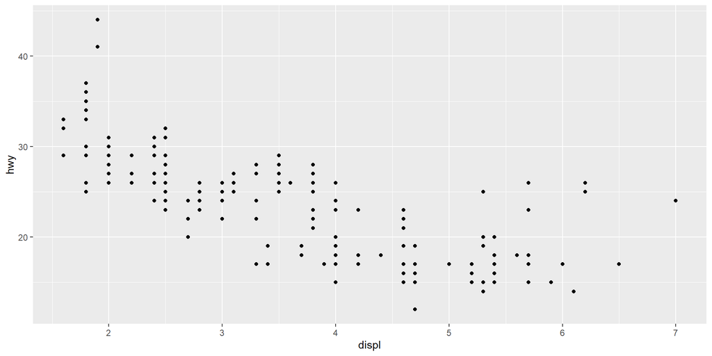

```r
library(ggplot2)

data(mpg)

ggplot(data = mpg, mapping = aes(x = displ, y = hwy)) +
  geom_point()
```

- How would you describe the relationship between displ and hwy?

## ggplot2

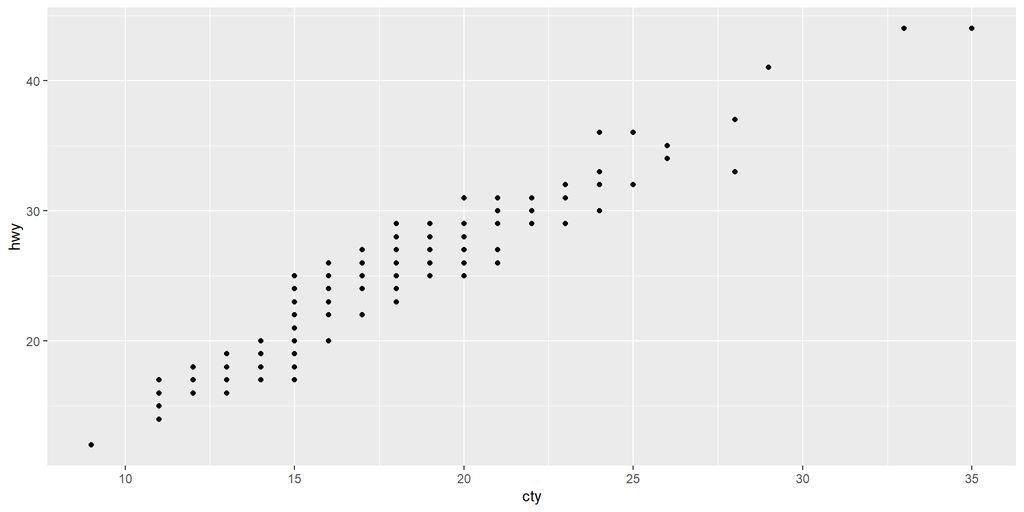

```r
ggplot(mpg, aes(cty, hwy)) +
  geom_point()
```

- How would you describe the relationship between cty and hwy?

## ggplot2

### Colour, size, shape and other aesthetic attributes

- Aesthetics are visual properties of the objects in the plot
  - colour, size, shape, linetype, fill, alpha
- Aesthetics can be mapped to variables in the data
  - aes(colour=variable)
  - aes(size=variable)
  - aes(shape=variable)
  - aes(linetype=variable)
  - aes(fill=variable)
  - aes(alpha=variable)

## ggplot2

Colour, size, shape and other aesthetic attributes

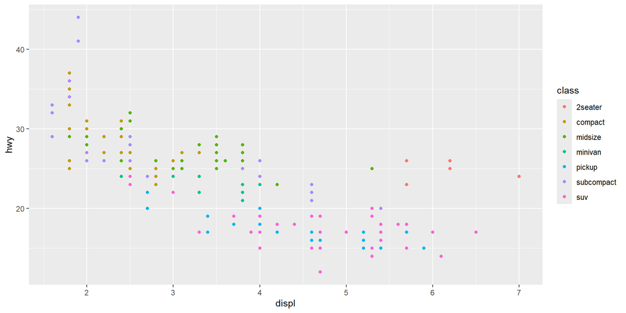

```r
ggplot(mpg, aes(displ, hwy, colour = class)) +
  geom_point()
```

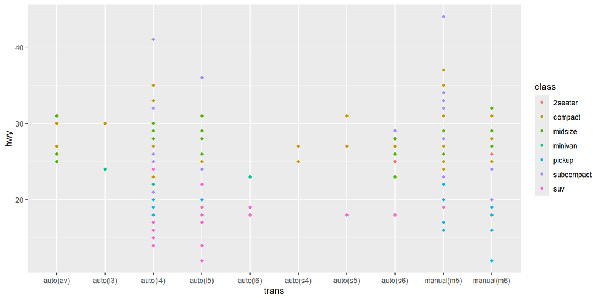

```r
ggplot(mpg, aes(trans, hwy, colour = class)) +
  geom_point()
```

## ggplot2 — labels

- Labels are important for making your plot understandable
  - xlab() and ylab() functions
  - labs() function

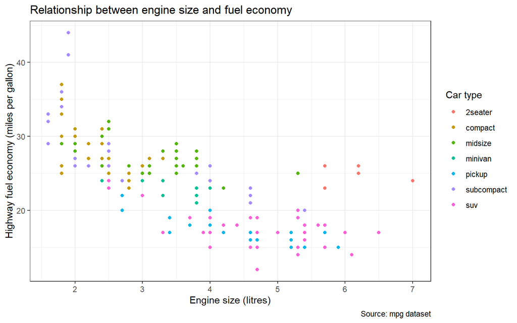

```r
ggplot(mpg, aes(displ, hwy)) +
  geom_point(aes(color = class)) +
  labs(
    x = "Engine size (litres)",
    y = "Highway fuel economy (miles per gallon)",
    title = "Relationship between engine size and fuel economy",
    color = "Car type",
    caption = "Source: mpg dataset"
  ) +
  theme_bw()
```

## ggplot2

### ggthemes

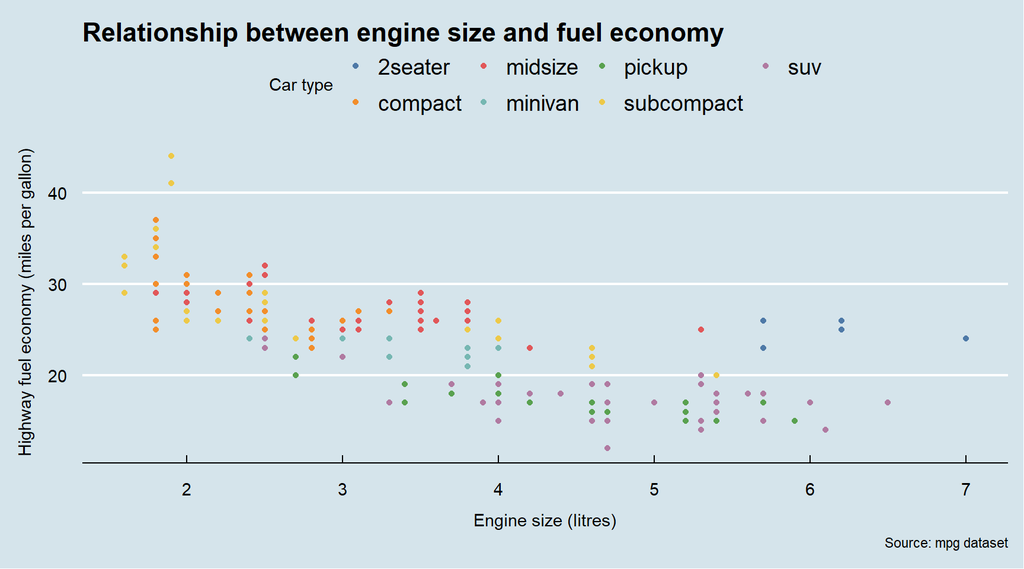

```r
library(ggthemes)

ggplot(mpg, aes(displ, hwy)) +
  geom_point(aes(color = class)) +
  labs(
    x = "Engine size (litres)",
    y = "Highway fuel economy (miles per gallon)",
    title = "Relationship between engine size and fuel economy",
    color = "Car type",
    caption = "Source: mpg dataset"
  ) +
  theme_economist() +
  scale_color_tableau() +
  theme(
    axis.title.x = element_text(margin = margin(t = 10)),
    axis.title.y = element_text(margin = margin(r = 10))
  )
```

## ggplot2 — Facets

- Facets allow you to create multiple plots that each display a subset of the data
  - facet_wrap() creates a grid of plots
  - facet_grid() creates a matrix of plots

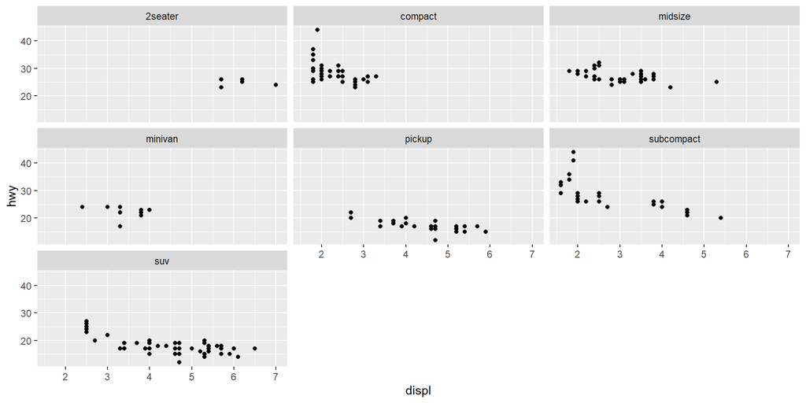

```r
ggplot(mpg, aes(displ, hwy)) +
  geom_point() +
  facet_wrap(~class)
```

## ggplot2

### Plot geoms

- Geoms are the geometric objects that represent the data in the plot
  - geom_point() creates a scatterplot
  - geom_smooth() creates a smoothed line plot
  - geom_histogram() creates a histogram
  - geom_boxplot() creates a boxplot
  - geom_bar() creates a bar plot
  - geom_line() creates a line plot
  - geom_vline() adds a vertical line to the plot
  - geom_hline() adds a horizontal line to the plot
  - geom_abline() adds a diagonal line to the plot

## ggplot2

### Adding a smoother to a plot

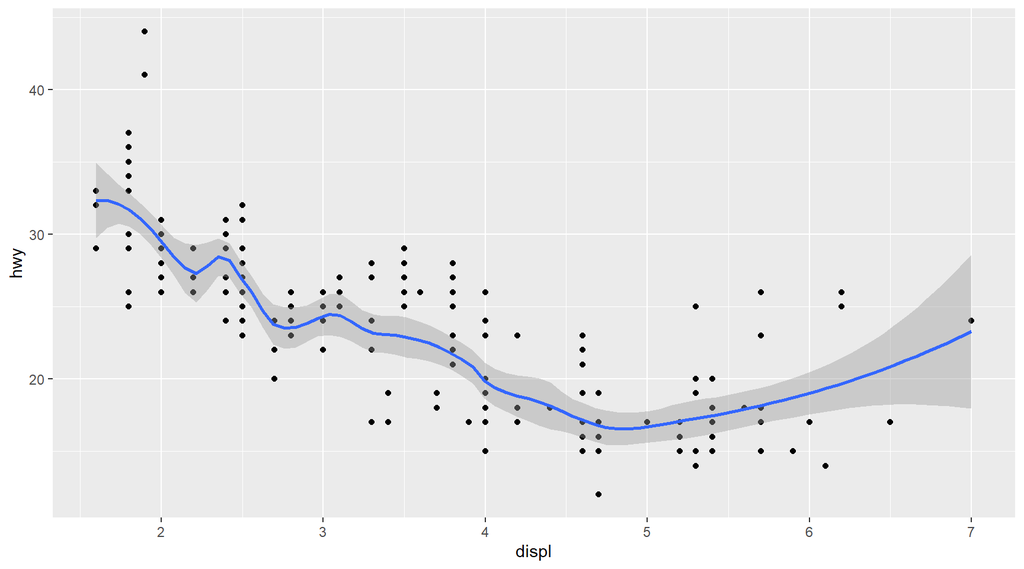

```r
ggplot(mpg, aes(displ, hwy)) +
  geom_point() +
  geom_smooth(span = 0.3)
```

## ggplot2 — Boxplots and related plots

- Boxplots, violin and jittered points are useful for visualizing the distribution of a continuous variable

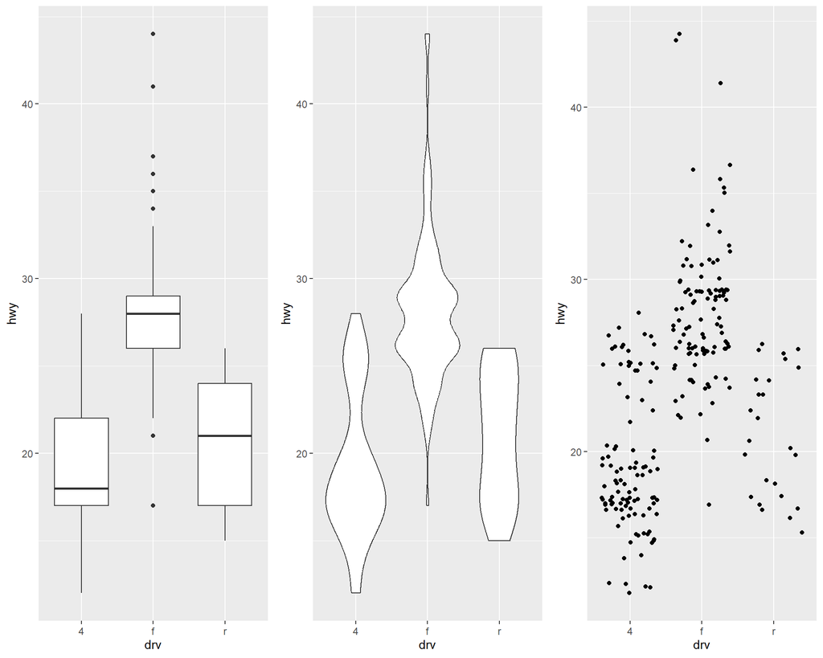

```r
library(ggpubr)

boxplot <- ggplot(mpg, aes(drv, hwy)) +
  geom_boxplot()

violin <- ggplot(mpg, aes(drv, hwy)) + geom_violin()


jitter <- ggplot(mpg, aes(drv, hwy)) +
  geom_jitter()

# use ggarrange() to arrange the three plots in a single row

ggarrange(boxplot, violin, jitter, ncol = 3)
```

- here we use [ggpubr](https://cran.r-project.org/web/packages/ggpubr/index.html) - a package for creating publication-ready plots

```r
library(ggpubr) # ggpubr is a package that provides functions for creating publication-ready plots

boxplot2<- ggboxplot(mpg, x = "drv", y = "hwy",
  color = "drv", palette = "jco",
  ylab = "Highway fuel economy (miles per gallon)", xlab = "Drive type"
)

violin2 <- ggviolin(mpg, x = "drv", y = "hwy",
  fill = "drv", palette = "jco",
  ylab = "Highway fuel economy (miles per gallon)", xlab = "Drive type"
)

jitter2<- ggscatter(mpg, x = "drv", y = "hwy",
  color = "drv", palette = "jco",
  ylab = "Highway fuel economy (miles per gallon)", xlab = "Drive type"
)

ggarrange(boxplot2, violin2, jitter2, ncol = 3)
```

[figure not shown]

## ggplot2 – Boxplots

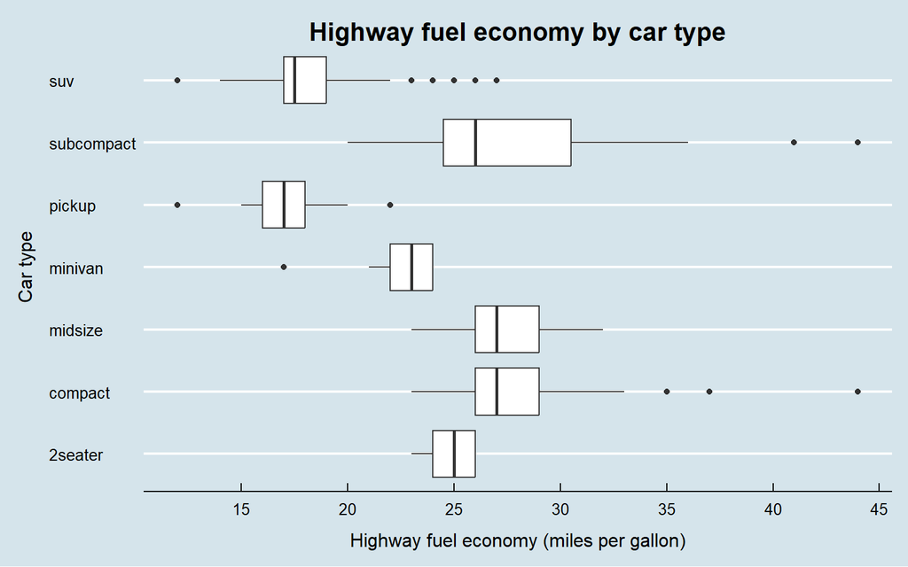

```r
ggplot(mpg, aes(class, hwy)) +
  geom_boxplot() +
  labs(
    title = "Highway fuel economy by car type",
    x = "Car type",
    y = "Highway fuel economy (miles per gallon)"
  ) +
  coord_flip() +
  theme_economist() +
  theme(
    plot.title = element_text(size = 16, face = "bold", hjust = 0.5),
    axis.title.x = element_text(size = 12, margin = margin(t = 10)),
    axis.title.y = element_text(size = 12, margin = margin(r = 10)),
    axis.text.x = element_text(size = 10, margin = margin(t = 5)),
    axis.text.y = element_text(size = 10, margin = margin(r = 5))
  ) +
  scale_y_continuous(breaks = seq(10, 50, by = 5))
```

## ggplot2 — Bar plots

- Bar plots are useful for visualizing the distribution of a categorical variable

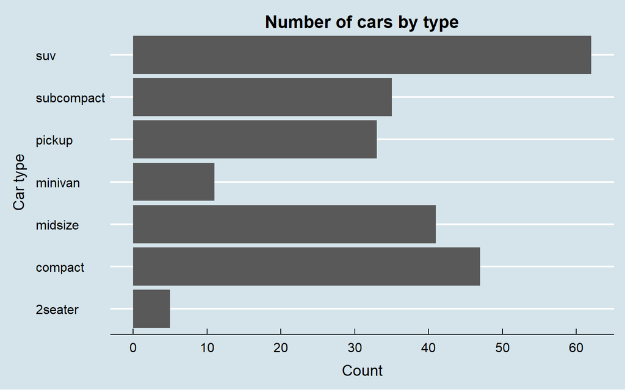

```r
ggplot(mpg, aes(class)) +
  geom_bar() +
  labs(
    title = "Number of cars by type",
    x = "Car type",
    y = "Count"
  ) +
  theme_economist() +
  theme(
    plot.title = element_text(size = 16, face = "bold", hjust = 0.5),
    axis.title.x = element_text(size = 14, margin = margin(t = 10)),
    axis.title.y = element_text(size = 14, margin = margin(r = 10)),
    axis.text.x = element_text(size = 12, margin = margin(t = 5)),
    axis.text.y = element_text(size = 12, margin = margin(r = 5))
  ) +
  scale_y_continuous(breaks = seq(0, 100, by = 10)) +
  coord_flip()
```

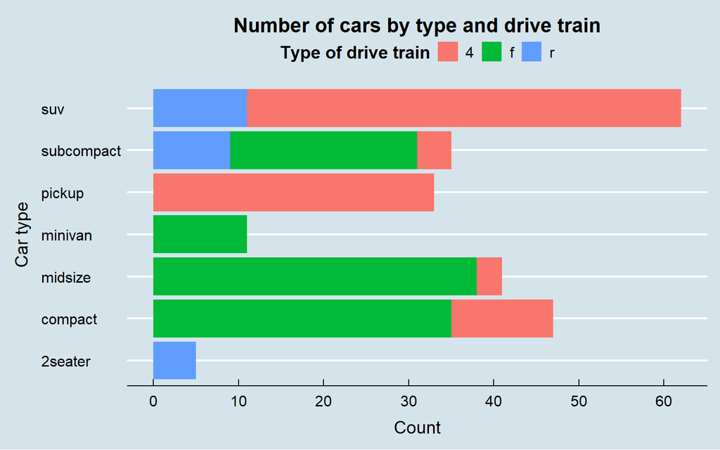

```r
ggplot(mpg, aes(class, fill = drv)) +
  geom_bar() +
  labs(
    title = "Number of cars by type and drive train",
    x = "Car type",
    y = "Count",
    fill = "Type of drive train"
  ) +
  theme_economist() +
  theme(
    plot.title = element_text(size = 16, face = "bold", hjust = 0.5),
    axis.title.x = element_text(size = 14, margin = margin(t = 10)),
    axis.title.y = element_text(size = 14, margin = margin(r = 10)),
    axis.text.x = element_text(size = 12, margin = margin(t = 5)),
    axis.text.y = element_text(size = 12, margin = margin(r = 5)),
    legend.title = element_text(size = 14, face = "bold"),
    legend.text = element_text(size = 12)
  ) +
  scale_y_continuous(breaks = seq(0, 100, by = 10)) +
  coord_flip()
```

## ggplot2

### Histograms and density plots

- Histograms and density plots are useful for visualizing the distribution of a continuous variable

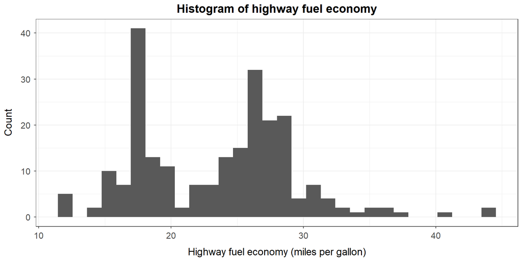

```r
ggplot(mpg, aes(hwy)) +
  geom_histogram(bins = 30) +
  labs(
    title = "Histogram of highway fuel economy",
    x = "Highway fuel economy (miles per gallon)",
    y = "Count"
  ) +
    theme_bw() +
  theme(
    plot.title = element_text(size = 16, face = "bold", hjust = 0.5),
    axis.title.x = element_text(size = 14, margin = margin(t = 10)),
    axis.title.y = element_text(size = 14, margin = margin(r = 10)),
    axis.text.x = element_text(size = 12, margin = margin(t = 5)),
    axis.text.y = element_text(size = 12, margin = margin(r = 5))
  )
```

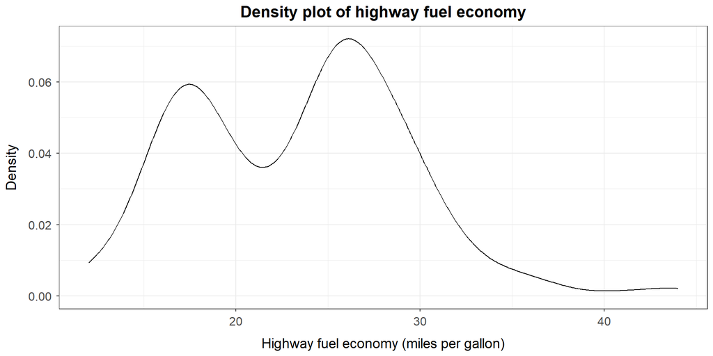

```r
ggplot(mpg, aes(hwy)) +
  geom_density() +
  labs(
    title = "Density plot of highway fuel economy",
    x = "Highway fuel economy (miles per gallon)",
    y = "Density"
  ) +
  theme_bw() +
  theme(
    plot.title = element_text(size = 16, face = "bold", hjust = 0.5),
    axis.title.x = element_text(size = 14, margin = margin(t = 10)),
    axis.title.y = element_text(size = 14, margin = margin(r = 10)),
    axis.text.x = element_text(size = 12, margin = margin(t = 5)),
    axis.text.y = element_text(size = 12, margin = margin(r = 5))
  )
```

## ggplot2

### Histograms and density plots

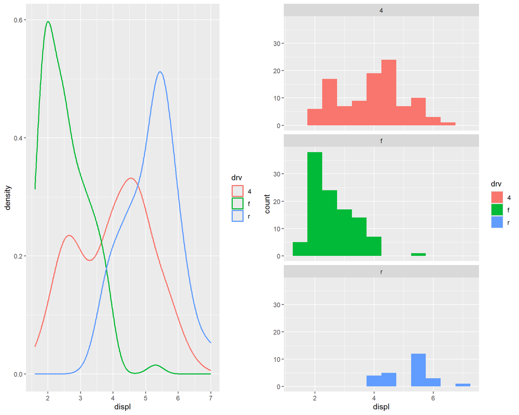

```r
den <- ggplot(mpg, aes(displ, colour = drv)) +
  geom_density(linewidth = 0.8)

hist <- ggplot(mpg, aes(displ, fill = drv)) +
  geom_histogram(binwidth = 0.5) +
  facet_wrap(~drv, ncol = 1)

ggarrange(den, hist, ncol = 2)
```

## ggplot2

### [ggsave](https://ggplot2.tidyverse.org/reference/ggsave.html) - save the graph as an image file

```r
ggsave(filename = "mpg_displ.png", width = 6, height = 4)
```

## Example - toy imports to the US from 1996-2005

- it is drawn from Scott (2021)

```r
library(tidyverse)

toy_imports <- read_csv(
  "https://raw.githubusercontent.com/kwan-MSDA/Bootcamp_2024/main/dataset/toyimports.csv"
)

head(toy_imports)
```

```
# A tibble: 6 × 8
  partner  year partner_name       product product_name US_report_import pop2000
  <chr>   <dbl> <chr>                <dbl> <chr>                   <dbl>   <dbl>
1 ARE      1998 United Arab Emira…  950341 "Toys repre…             1.06  3.25e6
2 ARE      2000 United Arab Emira…  950349 "Toys repre…            12.0   3.25e6
3 ARE      2003 United Arab Emira…  950349 "Toys repre…             4.65  3.25e6
4 ARE      2005 United Arab Emira…  950320 "Reduced-si…            49.2   3.25e6
5 ARG      1996 Argentina           950341 "Toys repre…             0     3.69e7
6 ARG      1996 Argentina           950310 "Electric t…            10.8   3.69e7
# ℹ 1 more variable: region <dbl>
```

## Example - toy imports to the US from 1996-2005

- Task: make a graph showing total toy imports over time for the U.S.’s top 5 trading partners by total dollar value of toys imported

```r
country_total <- toy_imports %>%
  group_by(partner_name) %>%
  summarize(total_import = sum(US_report_import)) %>%
  arrange(desc(total_import)) %>%
  head(5)

country_total
```

```
# A tibble: 5 × 2
  partner_name     total_import
  <chr>                   <dbl>
1 China               26842305.
2 Denmark              1034990.
3 Canada                572309.
4 Hong Kong, China      545186.
5 Switzerland           400969.
```

## More Example - toy imports to the US from 1996-2005

```r
top5_partners <- c(
  "China",
  "Denmark",
  "Canada",
  "Hong Kong, China",
  "Switzerland"
)

options(scipen = 999)

library(ggthemes)
library(scales)
library(plotly)

p <- toy_imports %>%
  filter(partner_name %in% top5_partners) %>%
  group_by(year, partner_name) %>%
  summarize(total_import = sum(US_report_import)) %>%
  ggplot(aes(year, total_import, color = partner_name)) +
  geom_line(size = 1.18) +
  labs(
    title = "Toy imports from the U.S.'s top-5 partners, 1996-2005",
    x = "Year",
    y = "Dollar value of imports (log scale)",
    color = "Import Region"
  ) +
  scale_x_continuous(breaks = 1996:2005) +
  scale_y_log10(
    breaks = trans_breaks("log10", function(x) 10^x),
    labels = trans_format("log10", math_format(.x))
  ) +
  #labels = trans_format("log10", math_format(10^.x))) +
  theme_economist() +
  theme(
    plot.title = element_text(
      size = 22,
      face = "bold",
      hjust = 0.5,
      margin = margin(b = 15)
    ), # Larger, bold, centered title
    axis.title.x = element_text(size = 16, margin = margin(t = 10)), # Larger x-axis label
    axis.title.y = element_text(size = 16, margin = margin(r = 15)), # Larger y-axis label with right margin for spacing
    axis.text = element_text(size = 12), # Larger tick labels
    axis.ticks.y = element_line(color = "black", size = 0.5), # Clearer y-ticks
    axis.ticks.length.y = unit(0.3, "cm"), # Slightly longer y-ticks for prominence
    legend.title = element_text(size = 18), # Larger legend title
    legend.text = element_text(size = 16), # Larger legend text
    legend.position = "right" # Position legend on the right (optional)
  )


ggplotly(p)
```

[interactive chart not shown]

## More Example

### The five coldest months in Rapid City from 1995 to 2011

```r
library(tidyverse)

rapidcity <- read_csv(
  "https://raw.githubusercontent.com/kwan-MSDA/Bootcamp_2024/main/dataset/rapidcity.csv"
)

top_5_coldest <- rapidcity %>%
  group_by(Year, Month) %>%
  summarize(
    avg_Temp = mean(Temp),
    lowest_temp = min(Temp),
    highest_temp = max(Temp)
  ) %>%
    arrange(avg_Temp) %>%
    round(1) %>%
    mutate(
      Month_Year = paste(month.abb[Month], Year, sep = "-"),
      .after = Month) %>%
      head(n = 5)

top_5_coldest
```

```
# A tibble: 5 × 6
# Groups:   Year [4]
   Year Month Month_Year avg_Temp lowest_temp highest_temp
  <dbl> <dbl> <chr>         <dbl>       <dbl>        <dbl>
1  1996     1 Jan-1996       14.9       -11           46.1
2  2009    12 Dec-2009       16.4        -2.6         35.6
3  2000    12 Dec-2000       17.3        -9           38.8
4  1996    12 Dec-1996       17.5       -10.8         40.4
5  2001     2 Feb-2001       17.6        -3.9         40.8
```

## Interactive bar chart

```r
library(tidyverse)
library(plotly)

# Reshape data to long format
top_5_long <- top_5_coldest %>%
  pivot_longer(
    cols = c(avg_Temp, lowest_temp, highest_temp),
    names_to = "Temp_Type",
    values_to = "Temperature"
  ) %>%
    mutate(
      Temp_Type = factor(
      Temp_Type,
      levels = c("lowest_temp", "avg_Temp", "highest_temp"),
      labels = c("Lowest", "Average", "Highest")
      )
    )

# Create the ggplot
p <- ggplot(
  top_5_long,
  aes(x = Month_Year, y = Temperature, fill = Temp_Type)
) +
  geom_bar(
    stat = "identity",
    position = position_dodge(width = 1),
    alpha = 0.6
  ) +
  scale_fill_manual(
    values = c("Lowest" = "purple", "Average" = "blue", "Highest" = "red")
  ) +
  labs(
    title = "Top 5 Coldest Months in Rapid City",
    x = "Month-Year",
    y = "Temperature (°F)",
    fill = "Temperature Type"
  ) + # Add legend title
  theme_minimal() +
  theme(
    legend.title = element_text(face = "bold", size = 12, color = "black"), # Style legend title
    legend.text = element_text(size = 10), # Style legend text
    axis.text.x = element_text(angle = 45, hjust = 1) # Rotate x-axis labels
  )

# Convert to an interactive HTML widget
p %>%
  ggplotly()
```

[interactive chart not shown]

## One more Example - Survival on the Titanic

Q: how did survival among adult passengers vary by sex and cabin class?

```r
titanic <- read_csv(
  "https://raw.githubusercontent.com/kwan-MSDA/Bootcamp_2024/main/dataset/titanic.csv"
)

head(titanic)
```

```
# A tibble: 6 × 5
  name                            survived sex       age passengerClass
  <chr>                           <chr>    <chr>   <dbl> <chr>
1 Allen, Miss. Elisabeth Walton   yes      female 29     1st
2 Allison, Master. Hudson Trevor  yes      male    0.917 1st
3 Allison, Miss. Helen Loraine    no       female  2     1st
4 Allison, Mr. Hudson Joshua Crei no       male   30     1st
5 Allison, Mrs. Hudson J C (Bessi no       female 25     1st
6 Anderson, Mr. Harry             yes      male   48     1st
```

```r
surv_adults <- titanic %>%
  mutate(Adult = age >= 18) %>%
  filter(Adult) %>%
  group_by(sex, passengerClass) %>%
  summarize(
    total_count = n(),
    survived = sum(survived == "yes"),
    survival_rate = survived / total_count
  )


surv_adults
```

```
# A tibble: 6 × 5
# Groups:   sex [2]
  sex    passengerClass total_count survived survival_rate
  <chr>  <chr>                <int>    <int>         <dbl>
1 female 1st                    125      121        0.968
2 female 2nd                     85       74        0.871
3 female 3rd                    106       47        0.443
4 male   1st                    144       47        0.326
5 male   2nd                    143       12        0.0839
6 male   3rd                    289       45        0.156
```

## An Example - Survival on the Titanic

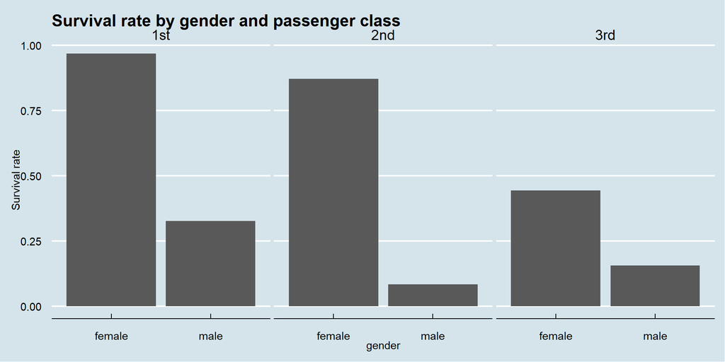

```r
library(ggthemes)

ggplot(surv_adults) +
  geom_col(aes(x = sex, y = survival_rate)) +
  facet_wrap(~passengerClass, nrow = 1) +
  labs(
    title = "Survival rate by gender and passenger class",
    y = "Survival rate",
    x = "gender"
  ) +
  theme_economist()
```

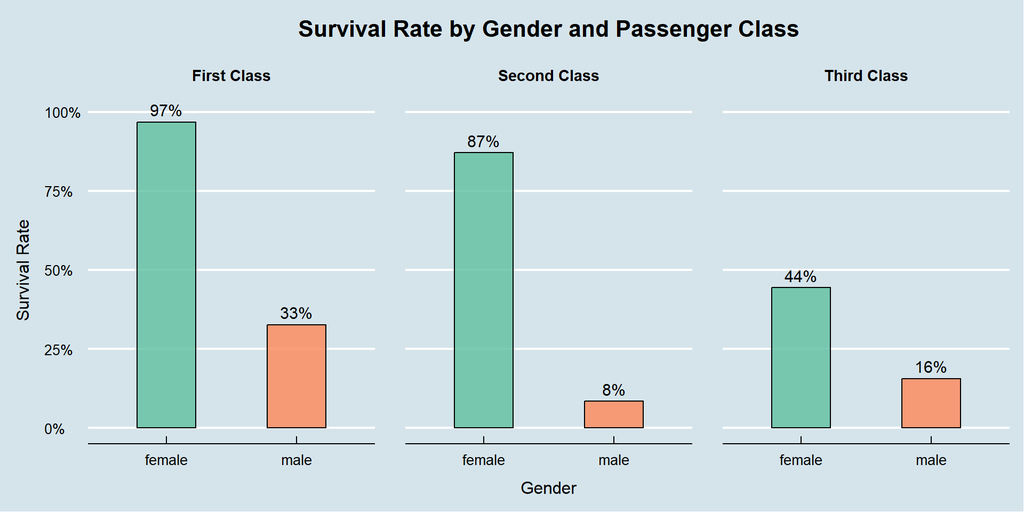

```r
library(ggplot2)
library(ggthemes)
library(scales) # For percent formatting

class_labels <- function(passengerClass) {
  dplyr::case_when(
    passengerClass == "1st" ~ "First Class",
    passengerClass == "2nd" ~ "Second Class",
    passengerClass == "3rd" ~ "Third Class",
    TRUE ~ as.character(passengerClass) # Fallback for unexpected values
  )
}

ggplot(surv_adults, aes(x = sex, y = survival_rate, fill = sex)) +
  geom_col(position = "dodge", width = 0.45, color = "black", alpha = 0.85) + # Add outline and transparency
  facet_wrap(
    ~passengerClass,
    nrow = 1,
    labeller = labeller(passengerClass = class_labels)
  ) + # Clear facet labels
  geom_text(
    aes(label = scales::percent(survival_rate, accuracy = 1)),
    vjust = -0.5,
    size = 4
  ) + # Add percentage labels above bars
  scale_y_continuous(
    labels = scales::percent_format(accuracy = 1),
    limits = c(0, 1),
    expand = c(0, 0.05)
  ) + # Y-axis as percentage, 0-1 range
  scale_fill_brewer(palette = "Set2") + # Colorblind-friendly palette
  labs(
    title = "Survival Rate by Gender and Passenger Class",
    y = "Survival Rate",
    x = "Gender"
  ) +
  theme_economist() +
  theme(
    plot.title = element_text(
      size = 16,
      face = "bold",
      hjust = 0.5,
      margin = margin(b = 15)
    ),
    axis.title.x = element_text(size = 12, margin = margin(t = 10)),
    axis.title.y = element_text(size = 12, margin = margin(r = 10)),
    axis.text.x = element_text(size = 10, margin = margin(t = 5)),
    axis.text.y = element_text(size = 10, margin = margin(r = 5)),
    strip.text = element_text(
      size = 11,
      face = "bold",
      margin = margin(t = 5, r = 5, b = 10, l = 5)
    ), # Increased bottom margin
    panel.spacing = unit(1.5, "lines"), # Increased space between facets
    legend.position = "none"
  )
```

## Extra: Gapminder data

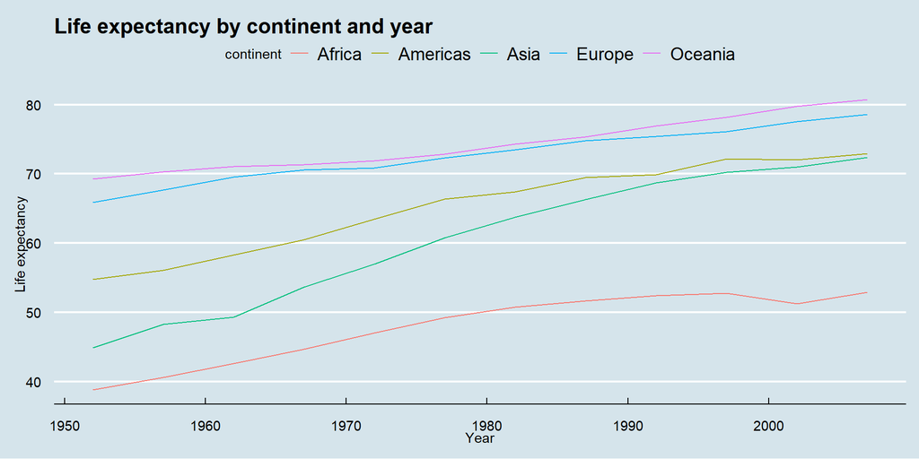

```r
library(gapminder)

data(gapminder)

gapminder %>%
  group_by(year, continent) %>%
  mutate(median_lifeExp = median(lifeExp)) %>%
  ggplot(aes(year, median_lifeExp, color = continent)) +
  geom_line() +
  labs(
    title = "Life expectancy by continent and year",
    x = "Year",
    y = "Life expectancy"
  ) +
  theme_economist()
```

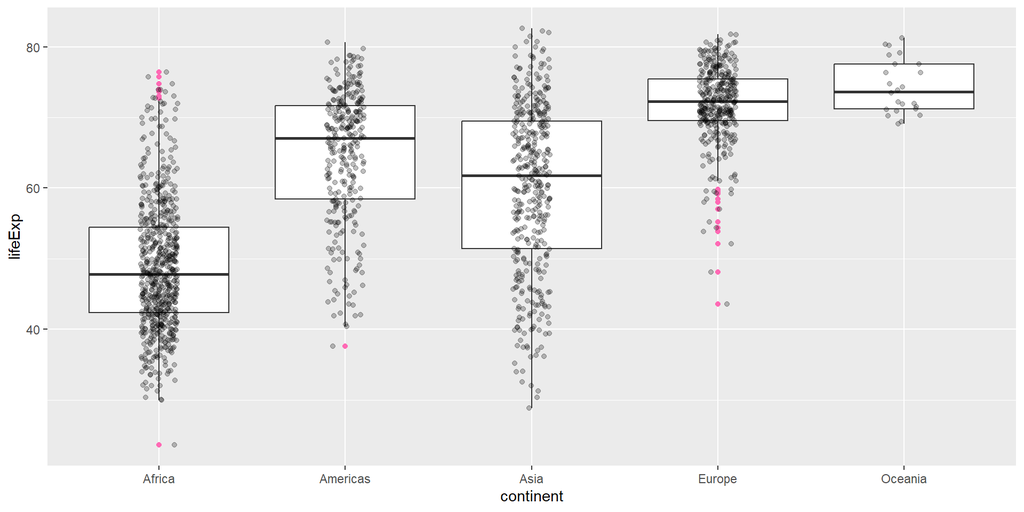

```r
ggplot(gapminder, aes(x = continent, y = lifeExp)) +
  geom_boxplot(outlier.colour = "hotpink") +
  geom_jitter(
    position = position_jitter(width = 0.1, height = 0),
    alpha = 1 / 4
  )
```

## Extra: Gapminder data

### this is from [BBC style](https://medium.com/bbc-visual-and-data-journalism/how-the-bbc-visual-and-data-journalism-team-works-with-graphics-in-r-ed0b35693535)

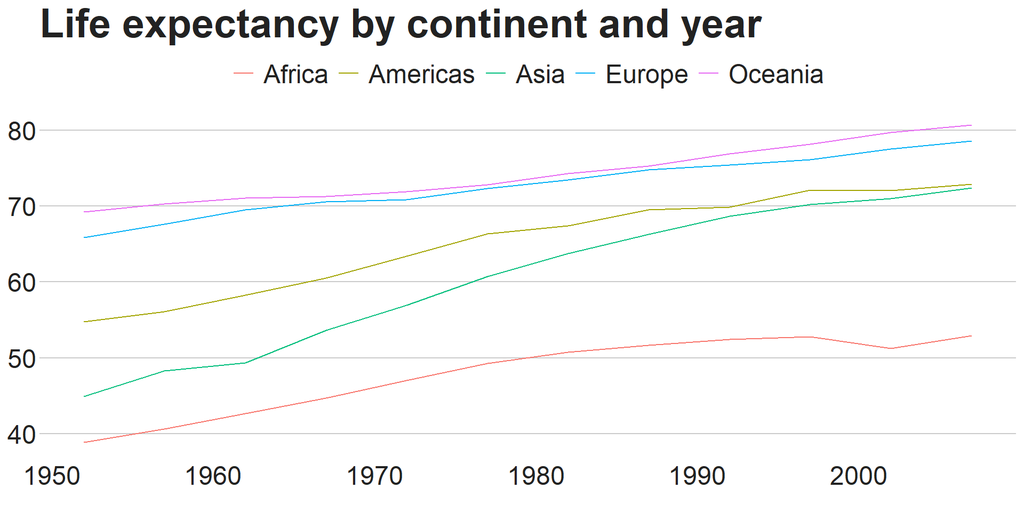

```r
# install.packages('devtools')
#devtools::install_github('bbc/bbplot'))

library(ggpubr)

source("https://raw.githubusercontent.com/kwan-MSDA/R/main/bbc_style.R")

gapminder %>%
  group_by(year, continent) %>%
  summarize(median_lifeExp = median(lifeExp)) %>%
  ggplot(aes(year, median_lifeExp, color = continent)) +
  geom_line() +
  labs(
    title = "Life expectancy by continent and year",
    x = "Year",
    y = "Life expectancy"
  ) +
  bbc_style()
```

## Extra: Gapminder data

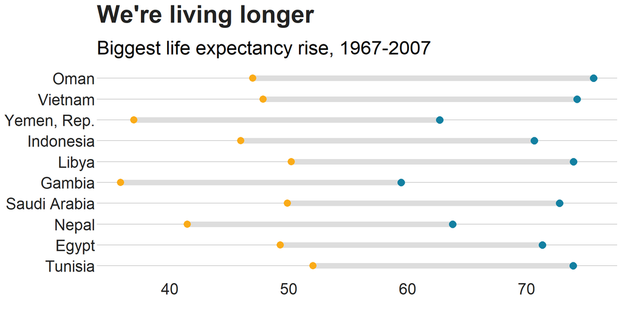

```r
library("ggalt")
library("tidyr")

library(gapminder)

dumbbell_df <- gapminder %>%
  filter(year == 1967 | year == 2007) %>%
  select(country, year, lifeExp) %>%
  spread(year, lifeExp) %>%
  mutate(gap = `2007` - `1967`) %>%
  arrange(desc(gap)) %>%
  head(10)

# Make a plot

ggplot(
  dumbbell_df,
  aes(x = `1967`, xend = `2007`, y = reorder(country, gap), group = country)
) +
  geom_dumbbell(
    colour = "#dddddd",
    size = 3,
    colour_x = "#FAAB18",
    colour_xend = "#1380A1"
  ) +
  bbc_style() +
  labs(
    title = "We're living longer",
    subtitle = "Biggest life expectancy rise, 1967-2007"
  )
```

## Extra: Gapminder data

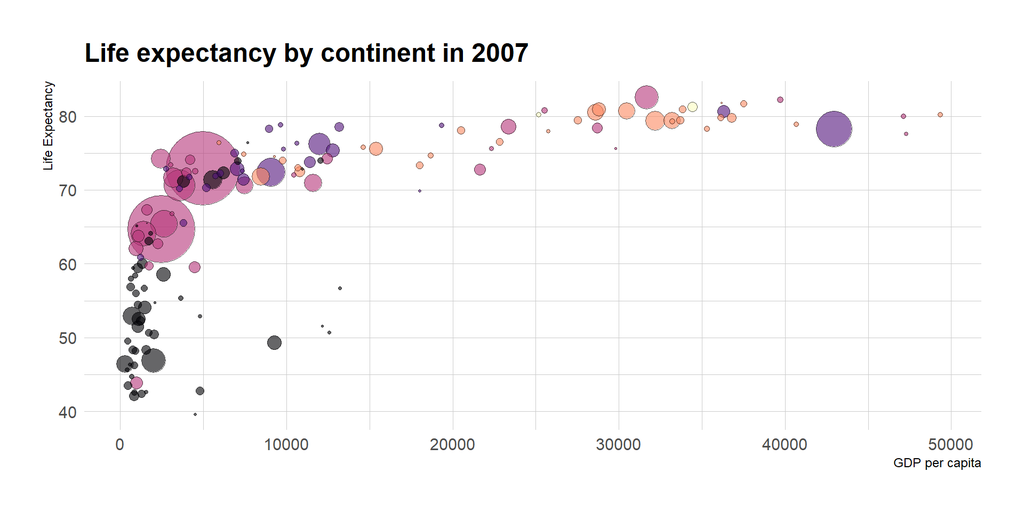

```r
library(hrbrthemes)
library(viridis)

gapminder %>%
  filter(year == 2007) %>%
  mutate(country = factor(country, levels = unique(country))) %>%
  arrange(desc(pop)) %>%
  ggplot(aes(x = gdpPercap, y = lifeExp, size = pop, fill = continent)) +
  geom_point(alpha = 0.6, shape = 21, color = "black") +
  scale_size(range = c(.1, 24), name = "Population (M)") +
  scale_fill_viridis(discrete = TRUE, guide = FALSE, option = "A") +
  theme_ipsum() +
  theme(legend.position = "none") +
  labs(
    title = "Life expectancy by continent in 2007",
    x = "GDP per capita",
    y = "Life Expectancy"
  )
```

## Extra: Gapminder data

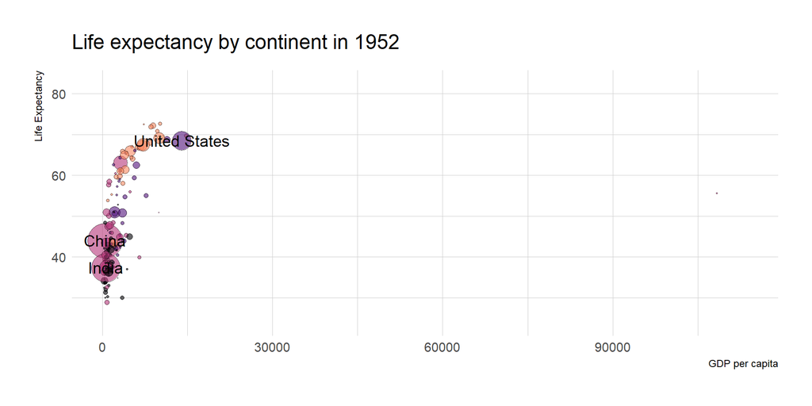

```r
library(gganimate)

gapminder %>%
  ggplot(aes(
    x = gdpPercap,
    y = lifeExp,
    size = pop,
    fill = continent,
    frame = year
  )) +
  geom_point(alpha = 0.6, shape = 21, color = "black") +
  scale_size(range = c(.1, 22), name = "Population (M)") +
  scale_fill_viridis(discrete = TRUE, guide = FALSE, option = "A") +
  theme_ipsum() +
  theme(legend.position = "none") +
  labs(
    title = "Life expectancy by continent in {frame_time}",
    x = "GDP per capita",
    y = "Life Expectancy"
  ) +
  geom_text(
    data = gapminder %>% filter(pop > 1e+8),
    aes(label = country),
    size = 5,
    nudge_x = 0.1,
    nudge_y = 0.1
  ) +
  transition_time(year) +
  enter_fade() +
  exit_fade()
```

```r
anim_save("gapminder_gganimate.gif")
```

## Extra: Gapminder data

### [source](http://euclid.psych.yorku.ca/www/psy6135/tutorials/gapminder.html)

```r
library(plotly)
library(hrbrthemes)
library(viridis)

g <- crosstalk::SharedData$new(
  gapminder %>%
    mutate(country = factor(country, levels = unique(country))) %>%
    arrange(desc(pop)),
  ~continent
)
gg <- g %>%
  ggplot(aes(x = gdpPercap, y = lifeExp, fill = continent, frame = year)) +
  geom_point(aes(size = pop, alpha = 0.6, ids = country)) +
  scale_size(range = c(.1, 24), name = "Population (M)") +
  scale_fill_viridis(discrete = TRUE, guide = FALSE, option = "A") +
  scale_alpha(range = c(0.6, 1), guide = FALSE) +
  theme_ipsum() +
  # theme(legend.position="none")+
  labs(
    title = "Life expectancy by continent between 1952-2007",
    x = "GDP per capita",
    y = "Life Expectancy"
  )

ggplotly(gg, height = 500, width = 800)
```

[interactive chart not shown]

## References

Imai, Kosuke, and Nora Webb Williams. 2022. *Quantitative Social Science : An Introduction in Tidyverse*. Princeton University Press.

Scott, James. 2021. “Data Science in r: A Gentle Introduction.” https://bookdown.org/jgscott/DSGI/.

Wickham, Hadley. 2016. *Ggplot2 : Elegrant Graphics for Data Analysis*. Second edition. Use r! Springer.

Wickham, Hadley. 2019. *Advanced r*. Second edition. The r Series. CRC Press.

Wickham, Hadley, and Garrett Grolemund. 2023. *R for Data Science : Import, Tidy, Transform, Visualize, and Model Data*. Second edition. O’Reilly.